# Twitter US Airline Sentiment - Problem Statement

### Background and Context:

Twitter possesses 330 million monthly active users, which allows businesses to reach a broad population and connect with customers without intermediaries. On the other hand, there’s so much information that it’s difficult for brands to quickly detect negative social mentions that could harm their business.

That's why sentiment analysis/classification, which involves monitoring emotions in conversations on social media platforms, has become a key strategy in social media marketing.

Listening to how customers feel about the product/service on Twitter allows companies to understand their audience, keep on top of what’s being said about their brand and their competitors, and discover new trends in the industry.

### Data Description:

A sentiment analysis job about the problems of each major U.S. airline. Twitter data was scraped from February of 2015 and contributors were asked to first classify positive, negative, and neutral tweets, followed by categorizing negative reasons (such as "late flight" or "rude service").

### Dataset:

The dataset has the following columns:

- tweet_id
- airline_sentiment
- airline_sentiment_confidence
- negativereason
- negativereason_confidence
- airline
- airline_sentiment_gold
- name
- negativereason_gold
- retweet_count
- text
- tweet_coord
- tweet_created
- tweet_location
- user_timezone

# Import Libraries

```python
!pip install contractions
```

```python
import numpy as np
import pandas as pd
```

```python
import matplotlib.pyplot as plt
import seaborn as sns
```

```python
from PIL import Image
from wordcloud import WordCloud, STOPWORDS, ImageColorGenerator
```

```python
from sklearn.model_selection import train_test_split
from sklearn.metrics import accuracy_score, classification_report, confusion_matrix
from sklearn.tree import DecisionTreeClassifier
```

```python
import warnings
warnings.filterwarnings('ignore')
```

# Load Data

```python
from google.colab import drive
drive.mount('/content/drive')
```

```python
tweets = pd.read_csv('/content/drive/MyDrive/Python Course/Tweets.csv')
```

```python
data = tweets.copy()
```

```python
data.head()
```

|  | tweet_id | airline_sentiment | airline_sentiment_confidence | negativereason | negativereason_confidence | airline | airline_sentiment_gold | name | negativereason_gold | retweet_count | text | tweet_coord | tweet_created | tweet_location | user_timezone |
| --- | --- | --- | --- | --- | --- | --- | --- | --- | --- | --- | --- | --- | --- | --- | --- |
| 0 | 570306133677760513 | neutral | 1.0000 | NaN | NaN | Virgin America | NaN | cairdin | NaN | 0 | @VirginAmerica What @dhepburn said. | NaN | 2015-02-24 11:35:52 -0800 | NaN | Eastern Time (US & Canada) |
| 1 | 570301130888122368 | positive | 0.3486 | NaN | 0.0000 | Virgin America | NaN | jnardino | NaN | 0 | @VirginAmerica plus you've added commercials to the experience... tacky. | NaN | 2015-02-24 11:15:59 -0800 | NaN | Pacific Time (US & Canada) |
| 2 | 570301083672813571 | neutral | 0.6837 | NaN | NaN | Virgin America | NaN | yvonnalynn | NaN | 0 | @VirginAmerica I didn't today... Must mean I need to take another trip! | NaN | 2015-02-24 11:15:48 -0800 | Lets Play | Central Time (US & Canada) |
| 3 | 570301031407624196 | negative | 1.0000 | Bad Flight | 0.7033 | Virgin America | NaN | jnardino | NaN | 0 | @VirginAmerica it's really aggressive to blast obnoxious "entertainment" in your guests' faces &amp; they have little recourse | NaN | 2015-02-24 11:15:36 -0800 | NaN | Pacific Time (US & Canada) |
| 4 | 570300817074462722 | negative | 1.0000 | Can't Tell | 1.0000 | Virgin America | NaN | jnardino | NaN | 0 | @VirginAmerica and it's a really big bad thing about it | NaN | 2015-02-24 11:14:45 -0800 | NaN | Pacific Time (US & Canada) |

- data imported correctly

# Overview of the Data

```python
data.shape
```

```
(14640, 15)
```

- There are 15 columns and 14,640 rows in the dataset.

```python
data.info()
```

```
<class 'pandas.core.frame.DataFrame'>
RangeIndex: 14640 entries, 0 to 14639
Data columns (total 15 columns):
 #   Column                        Non-Null Count  Dtype
---  ------                        --------------  -----
 0   tweet_id                      14640 non-null  int64
 1   airline_sentiment             14640 non-null  object
 2   airline_sentiment_confidence  14640 non-null  float64
 3   negativereason                9178 non-null   object
 4   negativereason_confidence     10522 non-null  float64
 5   airline                       14640 non-null  object
 6   airline_sentiment_gold        40 non-null     object
 7   name                          14640 non-null  object
 8   negativereason_gold           32 non-null     object
 9   retweet_count                 14640 non-null  int64
 10  text                          14640 non-null  object
 11  tweet_coord                   1019 non-null   object
 12  tweet_created                 14640 non-null  object
 13  tweet_location                9907 non-null   object
 14  user_timezone                 9820 non-null   object
dtypes: float64(2), int64(2), object(11)
memory usage: 1.7+ MB
```

- We have mostly object data types with 2 integer columns and 2 float columns.
- There are several columns with missing values.

```python
data.isnull().sum()
```

```
tweet_id                            0
airline_sentiment                   0
airline_sentiment_confidence        0
negativereason                   5462
negativereason_confidence        4118
airline                             0
airline_sentiment_gold          14600
name                                0
negativereason_gold             14608
retweet_count                       0
text                                0
tweet_coord                     13621
tweet_created                       0
tweet_location                   4733
user_timezone                    4820
dtype: int64
```

- airline_sentiment_gold and negativereason_gold are both have null values for nearly all entries.
- tweet_coord column also has a majority of null values for the column.
- The text column, and airline_sentiment, both have 0 null values.

```python
data.duplicated().sum()
```

```
36
```

- It looks like we have 36 duplicated rows in the dataset
- Let's go ahead and drop these duplicate rows

```python
data.drop_duplicates(inplace=True)
```

- Now that we have dropped the duplicated rows, we need to reset the index for out dataset so that we don't have gaps in the index count where these rows used to be located.

```python
data.reset_index(drop=True)
```

|  | tweet_id | airline_sentiment | airline_sentiment_confidence | negativereason | negativereason_confidence | airline | airline_sentiment_gold | name | negativereason_gold | retweet_count | text | tweet_coord | tweet_created | tweet_location | user_timezone |
| --- | --- | --- | --- | --- | --- | --- | --- | --- | --- | --- | --- | --- | --- | --- | --- |
| 0 | 570306133677760513 | neutral | 1.0000 | NaN | NaN | Virgin America | NaN | cairdin | NaN | 0 | @VirginAmerica What @dhepburn said. | NaN | 2015-02-24 11:35:52 -0800 | NaN | Eastern Time (US & Canada) |
| 1 | 570301130888122368 | positive | 0.3486 | NaN | 0.0000 | Virgin America | NaN | jnardino | NaN | 0 | @VirginAmerica plus you've added commercials to the experience... tacky. | NaN | 2015-02-24 11:15:59 -0800 | NaN | Pacific Time (US & Canada) |
| 2 | 570301083672813571 | neutral | 0.6837 | NaN | NaN | Virgin America | NaN | yvonnalynn | NaN | 0 | @VirginAmerica I didn't today... Must mean I need to take another trip! | NaN | 2015-02-24 11:15:48 -0800 | Lets Play | Central Time (US & Canada) |
| 3 | 570301031407624196 | negative | 1.0000 | Bad Flight | 0.7033 | Virgin America | NaN | jnardino | NaN | 0 | @VirginAmerica it's really aggressive to blast obnoxious "entertainment" in your guests' faces &amp; they have little recourse | NaN | 2015-02-24 11:15:36 -0800 | NaN | Pacific Time (US & Canada) |
| 4 | 570300817074462722 | negative | 1.0000 | Can't Tell | 1.0000 | Virgin America | NaN | jnardino | NaN | 0 | @VirginAmerica and it's a really big bad thing about it | NaN | 2015-02-24 11:14:45 -0800 | NaN | Pacific Time (US & Canada) |
| ... | ... | ... | ... | ... | ... | ... | ... | ... | ... | ... | ... | ... | ... | ... | ... |
| 14599 | 569587686496825344 | positive | 0.3487 | NaN | 0.0000 | American | NaN | KristenReenders | NaN | 0 | @AmericanAir thank you we got on a different flight to Chicago. | NaN | 2015-02-22 12:01:01 -0800 | NaN | NaN |
| 14600 | 569587371693355008 | negative | 1.0000 | Customer Service Issue | 1.0000 | American | NaN | itsropes | NaN | 0 | @AmericanAir leaving over 20 minutes Late Flight. No warnings or communication until we were 15 minutes Late Flight. That's called shitty customer svc | NaN | 2015-02-22 11:59:46 -0800 | Texas | NaN |
| 14601 | 569587242672398336 | neutral | 1.0000 | NaN | NaN | American | NaN | sanyabun | NaN | 0 | @AmericanAir Please bring American Airlines to #BlackBerry10 | NaN | 2015-02-22 11:59:15 -0800 | Nigeria,lagos | NaN |
| 14602 | 569587188687634433 | negative | 1.0000 | Customer Service Issue | 0.6659 | American | NaN | SraJackson | NaN | 0 | @AmericanAir you have my money, you change my flight, and don't answer your phones! Any other suggestions so I can make my commitment?? | NaN | 2015-02-22 11:59:02 -0800 | New Jersey | Eastern Time (US & Canada) |
| 14603 | 569587140490866689 | neutral | 0.6771 | NaN | 0.0000 | American | NaN | daviddtwu | NaN | 0 | @AmericanAir we have 8 ppl so we need 2 know how many seats are on the next flight. Plz put us on standby for 4 people on the next flight? | NaN | 2015-02-22 11:58:51 -0800 | dallas, TX | NaN |

14604 rows × 15 columns

- After dropping the duplicated columns and resetting the index we now have 14604 rows.

```python
data.nunique()
```

```
tweet_id                        14485
airline_sentiment                   3
airline_sentiment_confidence     1023
negativereason                     10
negativereason_confidence        1410
airline                             6
airline_sentiment_gold              3
name                             7701
negativereason_gold                13
retweet_count                      18
text                            14427
tweet_coord                       832
tweet_created                   14247
tweet_location                   3081
user_timezone                      85
dtype: int64
```

- We have 3 values for airline_sentiment
- 10 different negative reasons given
- There are 6 different airlines in the dataset
- The name column has only 7701 unique values so it looks like we have multiple tweets listed for some of the usernames.

# Exploratory Data Analysis(EDA)

### Let's start by looking at a pie chart for the breakdown of airline_sentiment across all tweets.

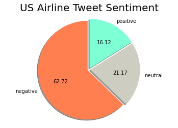

```python
colors = ['#FF7F50', '#CDCDC1', '#7FFFD4']

plot = plt.pie(data['airline_sentiment'].value_counts(),
               labels=data['airline_sentiment'].value_counts().index,
               colors=colors, explode=(0.03,0.03,0.03), shadow=True, startangle=90, autopct='%.2f')
plt.title('US Airline Tweet Sentiment', size=20)
plt.axis('equal')
plt.show()
```

- It looks like the majority of tweets have a negative sentiment.
- Positive tweets make up the smallest portion of sentiments in the dataset.

```python
# function for labeled barplot
def label_bar(data, feature, perc=False, n=None):
    '''
    Barplot with percentage
    data: data
    feature: data column
    perc: display percentages
    n: top n category levels
    '''

    total = len(data[feature])
    count = data[feature].nunique()
    if n is None:
        plt.figure(figsize=(count + 5, 7))
    else:
        plt.gifure(figsize=(n + 5, 7))

    plt.xticks(rotation=90, fontsize=14)
    ax = sns.countplot(
        data=data,
        x=feature,
        palette='gist_earth',
        order=data[feature].value_counts().index[:n].sort_values()
    )

    for p in ax.patches:
        if perc == True:
            label = '{:.1f}%'.format(
                100 * p.get_height() / total
            )
        else:
            label = p.get_height()

        x = p.get_x() + p.get_width() / 2
        y = p.get_height()

        ax.annotate(
            label,
            (x,y),
            ha='center',
            va='center',
            size=12,
            xytext=(0,5),
            textcoords='offset points'
        )

    plt.show()
```

### Different Airlines

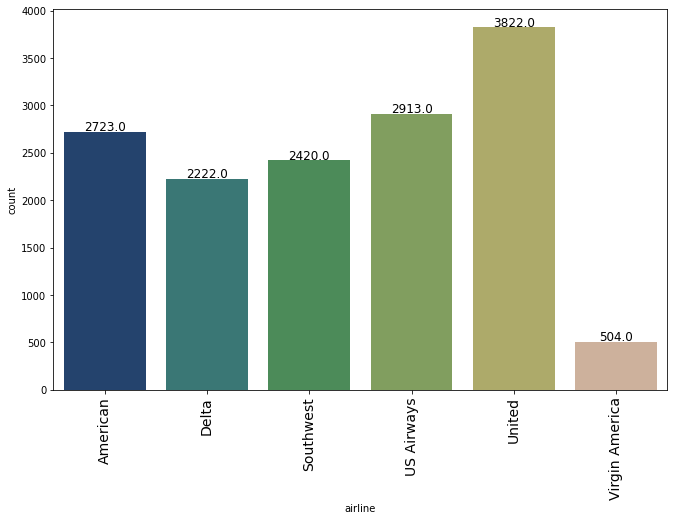

```python
label_bar(data, 'airline')
```

- There are 6 different airlines listed in the dataset.
- United is the most tweeted about airline by a decent margin, followed by US Airways, and then American.
- Virgin America is tweeted about siginificantly less than the other airlines in the dataset.

```python
# function for stacked barplot
def stacked_bar(data, predictor, target):
    '''
    plot stacked bar chart with category counts

    data: data
    predictor: independent variable
    target: dependent variable ('airline_sentiment')
    '''

    count = data[predictor].nunique()
    sorter = data[target].value_counts().index[-1]
    tab1 = pd.crosstab(data[predictor], data[target], margins=True).sort_values(
        by=sorter, ascending=False
    )
    print(tab1)
    print('*'*88)
    tab = pd.crosstab(data[predictor], data[target], normalize='index').sort_values(
        by=sorter, ascending=False
    )
    tab.plot(kind='bar', stacked=True, figsize=(count + 5, 8))
    plt.legend(
        loc='lower left',
        frameon=False
    )
    plt.legend(loc='upper left', bbox_to_anchor=(1, 1))
    plt.show()
```

### Distribution of Sentiment across each Airline

```
airline_sentiment  negative  neutral  positive    All
airline
All                    9159     3091      2354  14604
Southwest              1186      664       570   2420
Delta                   955      723       544   2222
United                 2633      697       492   3822
American               1941      455       327   2723
US Airways             2263      381       269   2913
Virgin America          181      171       152    504
```

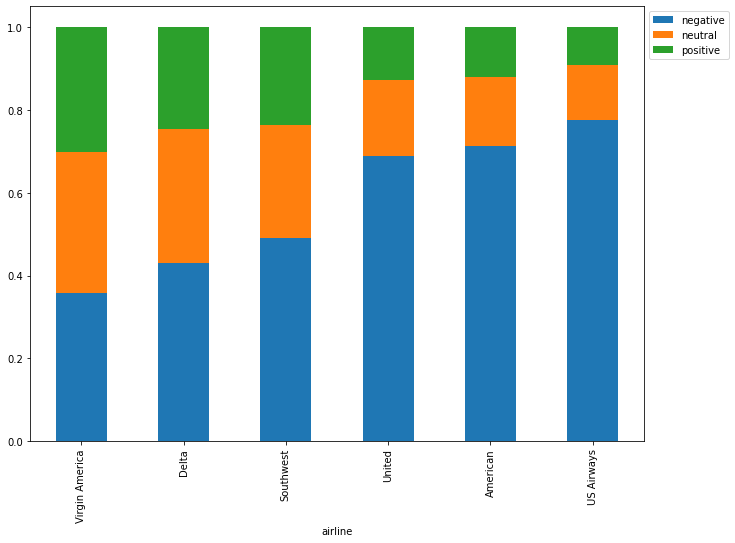

```python
stacked_bar(data, 'airline', 'airline_sentiment')
```

- Negative sentiment make up the largest portion of tweets for each airline.
- Virgin America while having the lowest overall tweet count, has the most evenly distributed sentiment amongst the 3 classifications. Virgin America also has the greatest positive percentage based on total their total tweets out of all 6 airlines.
- United had the most tweets total, but they still managed to have a slightly higher positive percentage than American or US Airways.
- US Airways has the lowest percentage of positive sentiment amongst all of the airlines in the data.

### Resons for negative sentiment

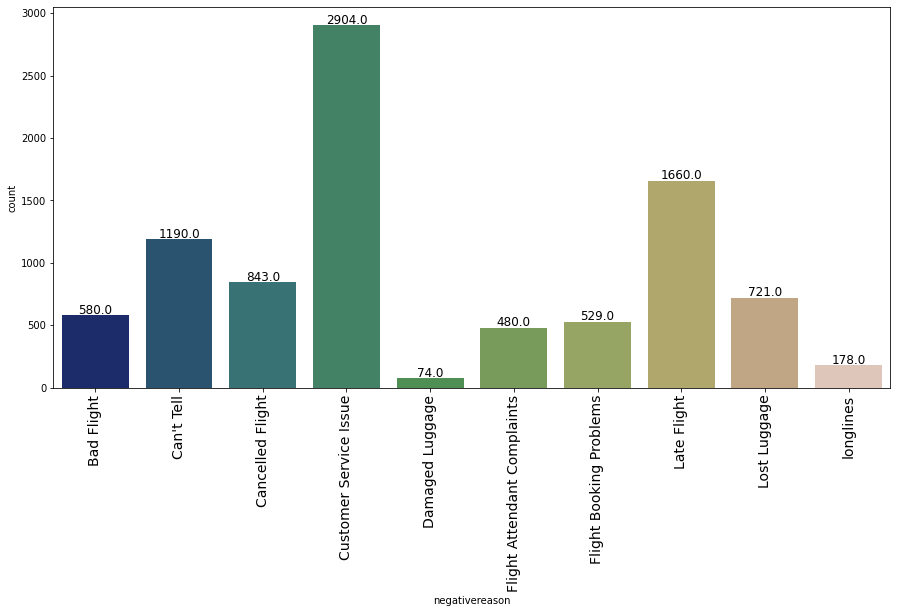

```python
label_bar(data, 'negativereason')
```

- Customer Service Issue is by far the largest reason for tweets with a negative sentiment.
- Late Flight is the 2nd biggest reason for negative sentiment.
- Can't Tell is the 3rd most attributed reason which unfortunately doesn't explain the nature of the negative tweet only that the sentiment was negative.
- After Can't Tell, the next most cited reasons are Cancelled Flight, and Lost Luggage.
- Damaged Luggage has the lowest negative reason counts.

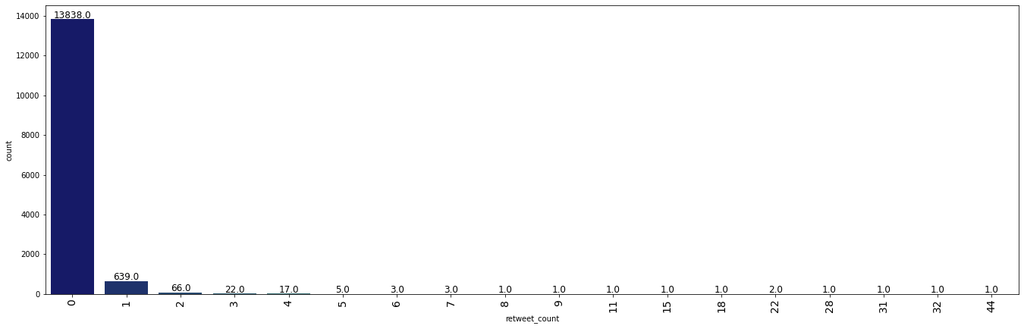

```python
label_bar(data, 'retweet_count')
```

- The majority of tweets did not receive any retweets
- Some received 1 retweet and a few received a greater number of retweets with 44 being the highest retweet count for one of the tweets.
- Let's take a look at several of the most retweeted, tweets to get an idea of what is being shared the most, what airlines are they aimed at, and what are their sentiments.

### A closer look at some of the most retweeted, tweets

```python
# finding the index for 44 retweets
retweet_44 = np.where(data['retweet_count'] == 44)
print(retweet_44)
```

```
(array([11596]),)
```

- The most retweeted message is at index 11596

```python
# display text with 44 retweets
data['text'][11596]
```

```
'@USAirways 5 hr flight delay and a delay when we land . Is that even real life ? Get me off this plane , I wanna go home 👠👠👠 (3 heel clicks)'
```

- This tweet is about US Airways and seems to have a negative sentiment based on multiple delays.

```python
# check sentiment for 44 retweets
data['airline_sentiment'][11596]
```

```
'negative'
```

- The sentiment matches up as it is indeed negative.
- Based on the overall distribution of sentiments, the most retweeted message having a negative sentiment makes sense.

```python
# finding the index for 32 retweets
retweet_32 = np.where(data['retweet_count'] == 32)
print(retweet_32)
```

```
(array([11582]),)
```

- The next highest retweet count comes in at 32 retweets and is at index position 11582.

```python
# display text with 32 retweets
data['text'][11582]
```

```
"@USAirways of course never again tho . Thanks for tweetin ur concern but not Doin anythin to fix what happened. I'll choose wiser next time"
```

- This one is also aimed at US Airways and has a clear negative sentiment, although we are not able to determine the reason for the negative tweet from the context of the message.

```python
# check sentiment for 32 retweets
data['airline_sentiment'][11582]
```

```
'negative'
```

- The sentiment is negative matching what we see reflected in the text

```python
# checking the reason listed for the negative sentiment with 32 retweets
data['negativereason'][11582]
```

```
"Can't Tell"
```

- This does indeed match the text as no context for the negative sentiment is given.

```python
# finding the index for 31 retweets
retweet_31 = np.where(data['retweet_count'] == 31)
print(retweet_31)
```

```
(array([7132]),)
```

```python
# display text with 31 retweets
data['text'][7132]
```

```
"STOP. USING.THIS.WORD. IF. YOU'RE. A. COMPANY. RT @JetBlue: Our fleet's on fleek. http://t.co/Fd2TNYcTrB"
```

- This is definitely a negative sentiment, and a clear miss from the marketing department on branding, but it appears to be aimed at JetBlue, which is not one of the 6 listed airlines in the dataset. We need to check which airline this is being attributed to.

```python
# check airline for the 31 retweets
data['airline'][7132]
```

```
'Delta'
```

- This tweet is being attributed to Delta despite being intended for JetBlue.
- After some outside research it appears JetBlue is a North American partner with Delta so this doesn't seem to be an error.

```python
# check sentiment for 31 retweets
data['airline_sentiment'][7132]
```

```
'negative'
```

- Negative sentiment is a match for the text in this tweet.

```python
# finding the index for 28 retweets
retweet_28 = np.where(data['retweet_count'] == 28)
print(retweet_28)
```

```
(array([9999]),)
```

```python
# display text with 28 retweets
data['text'][9999]
```

```
'@USAirways with this livery back in the day. http://t.co/EEqWVAMmiy'
```

- Another one of the most retweeted messages aimed at US Airways, although without being able to see the picture linked in the tweet it is not apparent what the sentiment should be.

```python
# check sentiment for 28 retweets
data['airline_sentiment'][9999]
```

```
'neutral'
```

- The sentiment is classified as neutral, which without the context of the image, is probably the best classification for this tweet as nothing in the text indicates it being identifiably positive or negative.

```python
# finding the indexes for 22 retweets
retweet_22 = np.where(data['retweet_count'] == 22)
print(retweet_22)
```

```
(array([5607, 7115]),)
```

- There are 2 messages with a retweet count of 22

```python
# display the first text with 22 retweets
data['text'][5607]
```

```
'@SouthwestAir beautiful day in Seattle! http://t.co/iqu0PPVq2S'
```

- We don't have access to the image included with this tweet either but the context seems to be positive from the text.

```python
# check sentiment for the first entry with 22 retweets
data['airline_sentiment'][5607]
```

```
'positive'
```

- Our interpretation of the text matches the positive sentiment label applied to this tweet.

```python
# display the second text with 22 retweets
data['text'][7115]
```

```
"can you not? RT @JetBlue Our fleet's on fleek. http://t.co/413GiAL0yl"
```

- As we can see another one of the most retweeted messages is also aimed at JetBlue's terrible marketing slogan.

```python
# check airline associated with second entry for 22 retweets
data['airline'][7115]
```

```
'Delta'
```

- This tweet @JetBlue is also attributed to Delta, which seems to confirm my outside research that JetBlue is indeed partnered with Delta.

```python
# check sentiment for the second entry with 22 retweets
data['airline_sentiment'][7115]
```

```
'negative'
```

- Not surprising that the sentiment for this is negative since it has a very similar message as the other tweet @JetBlue.

## Creating a wordcloud for the negative tweets

```python
# cleaning the text from the negative tweets
# to exclude hyperlink text, companies or people tagged with the @ sign, and the RT retweet label
negative_tweets = data[data['airline_sentiment'] == 'negative']
neg_words = ' '.join(negative_tweets['text'])
cleaned_neg_word = " ".join([word for word in neg_words.split()
                          if 'http' not in word
                          and not word.startswith('@')
                          and word != 'RT'])
```

```python
# Generating the wordcloud for the tweets with a negative sentiment
negative_wordcloud = WordCloud(stopwords=STOPWORDS,
                      background_color='black',
                      width=4500,
                      height=3000).generate(cleaned_neg_word)
```

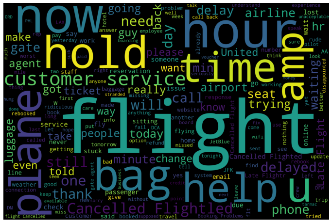

```python
# Displaying the negative wordcloud image
plt.figure(1, figsize=(12,12))
plt.imshow(negative_wordcloud)
plt.axis('off')
plt.show()
```

- Some of the more pronounced words from the negative tweets include "customer service", "hour", "hold", "time", "help", "cancelled flight", "delayed", and "bag".
- This seems pretty inline with some of the top negative reasons being customer service, cancelled/late/delayed flights, and lost bag/luggage.

## Creating a wordcloud for the positive tweets

```python
# cleaning the text from the positive tweets
# to exclude hyperlink text, companies or people tagged with the @ sign, and RT for retweet
positive_tweets = data[data['airline_sentiment'] == 'positive']
pos_words = ' '.join(positive_tweets['text'])
cleaned_pos_word = " ".join([word for word in pos_words.split()
                          if 'http' not in word
                          and not word.startswith('@')
                          and word != 'RT'])
```

```python
# Generating the wordcloud for the tweets with a positive sentiment
positive_wordcloud = WordCloud(stopwords=STOPWORDS,
                      background_color='black',
                      width=4500,
                      height=3000).generate(cleaned_pos_word)
```

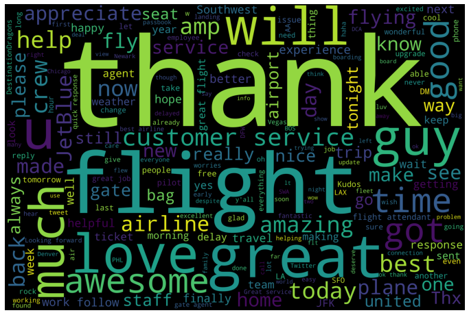

```python
# Displaying the positive wordcloud image
plt.figure(1, figsize=(12,12))
plt.imshow(positive_wordcloud)
plt.axis('off')
plt.show()
```

- Some of the more prominent words used in the positive tweets are "thank", "u", "good", "great", "awesome", "amazing", "guy", "much", "love", and "customer service".
- "Customer service" is represented about the same size in both the positive and negative wordclouds, which just goes to show that customer service really can make the difference between a positive or negative experience.
- Hopefully "customer service" appearing at roughly equal importance in both positive and negative sentiments will not cause an issue with mislabeling in our model.

## Creating a wordcloud for neutral tweets

```python
# cleaning the text from the neutral tweets
# to exclude hyperlink text, companies or people tagged with the @ sign, and RT for retweet
neutral_tweets = data[data['airline_sentiment'] == 'neutral']
ntrl_words = ' '.join(neutral_tweets['text'])
cleaned_ntrl_word = " ".join([word for word in ntrl_words.split()
                          if 'http' not in word
                          and not word.startswith('@')
                          and word != 'RT'])
```

```python
# Generating the wordcloud for the tweets with a neutral sentiment
neutral_wordcloud = WordCloud(stopwords=STOPWORDS,
                      background_color='black',
                      width=4500,
                      height=3000).generate(cleaned_ntrl_word)
```

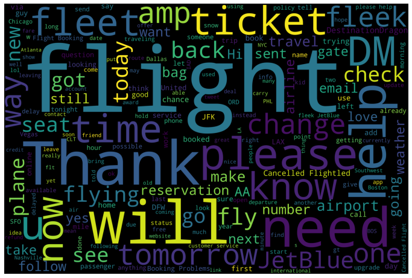

```python
# Displaying the neutral wordcloud image
plt.figure(1, figsize=(12,12))
plt.imshow(neutral_wordcloud)
plt.axis('off')
plt.show()
```

# Summary of EDA

# Data Pre-processing

- Remove html tags
- Remove URLs
- Replace contractions
- Remove numbers
- Remove @ mentions
- Tokenization
- Remove punctuation
- Remove non-ASCII characters
- Remove hashtags
- Convert to lowercase
- Remove Stopwords
- Lemmatize words
- Join words in list to convert

```python
import re, string, unicodedata
import nltk
nltk.download('wordnet')
nltk.download('punkt')
nltk.download('stopwords')
nltk.download('omw-1.4')
```

```
True
```

```python
from nltk.corpus import stopwords
from nltk.tokenize import word_tokenize, sent_tokenize
from nltk.stem.wordnet import WordNetLemmatizer
```

```python
# Creating a dataframe of only text and sentiment
data = data[['text', 'airline_sentiment']]

# Set column to display full text
pd.set_option('display.max_colwidth', None)

data.head()
```

|  | text | airline_sentiment |
| --- | --- | --- |
| 0 | @VirginAmerica What @dhepburn said. | neutral |
| 1 | @VirginAmerica plus you've added commercials to the experience... tacky. | positive |
| 2 | @VirginAmerica I didn't today... Must mean I need to take another trip! | neutral |
| 3 | @VirginAmerica it's really aggressive to blast obnoxious "entertainment" in your guests' faces &amp; they have little recourse | negative |
| 4 | @VirginAmerica and it's a really big bad thing about it | negative |

```python
data.shape
```

```
(14604, 2)
```

### Remove html tags

```python
from bs4 import BeautifulSoup
```

```python
def remove_html(text):
    soup = BeautifulSoup(text, 'html.parser')
    return soup.get_text()
```

```python
data['text'] = data['text'].apply(lambda x: remove_html(x))
```

```python
data.head()
```

|  | text | airline_sentiment |
| --- | --- | --- |
| 0 | @VirginAmerica What @dhepburn said. | neutral |
| 1 | @VirginAmerica plus you've added commercials to the experience... tacky. | positive |
| 2 | @VirginAmerica I didn't today... Must mean I need to take another trip! | neutral |
| 3 | @VirginAmerica it's really aggressive to blast obnoxious "entertainment" in your guests' faces & they have little recourse | negative |
| 4 | @VirginAmerica and it's a really big bad thing about it | negative |

### Remove URL text

```python
def remove_url(text):
    text = re.sub('http[s]?://(?:[a-zA-Z]|[0-9]|[$-_@.&+]|[!*\(\),]|(?:%[0-9a-fA-F][0-9a-fA-F]))+', '', text)
    return text
```

```python
data['text'] = data['text'].apply(lambda x: remove_url(x))
```

```python
data.head()
```

|  | text | airline_sentiment |
| --- | --- | --- |
| 0 | @VirginAmerica What @dhepburn said. | neutral |
| 1 | @VirginAmerica plus you've added commercials to the experience... tacky. | positive |
| 2 | @VirginAmerica I didn't today... Must mean I need to take another trip! | neutral |
| 3 | @VirginAmerica it's really aggressive to blast obnoxious "entertainment" in your guests' faces & they have little recourse | negative |
| 4 | @VirginAmerica and it's a really big bad thing about it | negative |

### Replace Contractions

```python
import contractions
```

```python
def expand_contractions(text):
    return contractions.fix(text)
```

```python
data['text'] = data['text'].apply(lambda x: expand_contractions(x))
```

```python
data.head()
```

|  | text | airline_sentiment |
| --- | --- | --- |
| 0 | @VirginAmerica What @dhepburn said. | neutral |
| 1 | @VirginAmerica plus you have added commercials to the experience... tacky. | positive |
| 2 | @VirginAmerica I did not today... Must mean I need to take another trip! | neutral |
| 3 | @VirginAmerica it is really aggressive to blast obnoxious "entertainment" in your guests' faces & they have little recourse | negative |
| 4 | @VirginAmerica and it is a really big bad thing about it | negative |

### Remove Numbers

```python
def remove_numbers(text):
    text = re.sub(r'\d+', '', text)
    return text
```

```python
data['text'] = data['text'].apply(lambda x: remove_numbers(x))
```

```python
data.head()
```

|  | text | airline_sentiment |
| --- | --- | --- |
| 0 | @VirginAmerica What @dhepburn said. | neutral |
| 1 | @VirginAmerica plus you have added commercials to the experience... tacky. | positive |
| 2 | @VirginAmerica I did not today... Must mean I need to take another trip! | neutral |
| 3 | @VirginAmerica it is really aggressive to blast obnoxious "entertainment" in your guests' faces & they have little recourse | negative |
| 4 | @VirginAmerica and it is a really big bad thing about it | negative |

### Remove "@" mentions

```python
def remove_mentions(text):
    text = re.sub(r'@\w+', '', text)
    return text
```

```python
data['text'] = data['text'].apply(lambda x: remove_mentions(x))
```

```python
data.head()
```

|  | text | airline_sentiment |
| --- | --- | --- |
| 0 | What said. | neutral |
| 1 | plus you have added commercials to the experience... tacky. | positive |
| 2 | I did not today... Must mean I need to take another trip! | neutral |
| 3 | it is really aggressive to blast obnoxious "entertainment" in your guests' faces & they have little recourse | negative |
| 4 | and it is a really big bad thing about it | negative |

### Word Tokenization

```python
data['text'] = data.apply(lambda row: nltk.word_tokenize(row['text']), axis=1)
```

```python
data.head()
```

|  | text | airline_sentiment |
| --- | --- | --- |
| 0 | [What, said, .] | neutral |
| 1 | [plus, you, have, added, commercials, to, the, experience, ..., tacky, .] | positive |
| 2 | [I, did, not, today, ..., Must, mean, I, need, to, take, another, trip, !] | neutral |
| 3 | [it, is, really, aggressive, to, blast, obnoxious, ``, entertainment, '', in, your, guests, ', faces, &, they, have, little, recourse] | negative |
| 4 | [and, it, is, a, really, big, bad, thing, about, it] | negative |

### Remove Punctuation

```python
def remove_punctuation(words):
    new_words = []
    for word in words:
        new_word = re.sub(r'[^\w\s]', '', word)
        if new_word != '':
            new_words.append(new_word)
    return new_words
```

```python
data['text'] = data.apply(lambda row: remove_punctuation(row['text']), axis=1)
```

```python
data.head()
```

|  | text | airline_sentiment |
| --- | --- | --- |
| 0 | [What, said] | neutral |
| 1 | [plus, you, have, added, commercials, to, the, experience, tacky] | positive |
| 2 | [I, did, not, today, Must, mean, I, need, to, take, another, trip] | neutral |
| 3 | [it, is, really, aggressive, to, blast, obnoxious, entertainment, in, your, guests, faces, they, have, little, recourse] | negative |
| 4 | [and, it, is, a, really, big, bad, thing, about, it] | negative |

### Remove non-ACSII characters

```python
def remove_non_ascii(words):
    new_words = []
    for word in words:
        new_word = unicodedata.normalize('NFKD', word).encode('ascii', 'ignore').decode('utf-8', 'ignore')
        new_words.append(new_word)
    return new_words
```

```python
data['text'] = data.apply(lambda row: remove_non_ascii(row['text']), axis=1)
```

```python
data.head()
```

|  | text | airline_sentiment |
| --- | --- | --- |
| 0 | [What, said] | neutral |
| 1 | [plus, you, have, added, commercials, to, the, experience, tacky] | positive |
| 2 | [I, did, not, today, Must, mean, I, need, to, take, another, trip] | neutral |
| 3 | [it, is, really, aggressive, to, blast, obnoxious, entertainment, in, your, guests, faces, they, have, little, recourse] | negative |
| 4 | [and, it, is, a, really, big, bad, thing, about, it] | negative |

### Remove Hashtags

```python
def remove_hashtags(words):
   new_words = []
   for word in words:
     new_word = re.sub(r'#\w+','',word)
     if new_word != '':
       new_words.append(new_word)
   return new_words
```

```python
data['text'] = data.apply(lambda row: remove_hashtags(row['text']), axis=1)
```

```python
data.head()
```

|  | text | airline_sentiment |
| --- | --- | --- |
| 0 | [What, said] | neutral |
| 1 | [plus, you, have, added, commercials, to, the, experience, tacky] | positive |
| 2 | [I, did, not, today, Must, mean, I, need, to, take, another, trip] | neutral |
| 3 | [it, is, really, aggressive, to, blast, obnoxious, entertainment, in, your, guests, faces, they, have, little, recourse] | negative |
| 4 | [and, it, is, a, really, big, bad, thing, about, it] | negative |

### Converting to lowercase

```python
def to_lowercase(words):
    new_words = []
    for word in words:
        new_word = word.lower()
        new_words.append(new_word)
    return new_words
```

```python
data['text'] = data.apply(lambda row: to_lowercase(row['text']), axis=1)
```

```python
data.head()
```

|  | text | airline_sentiment |
| --- | --- | --- |
| 0 | [what, said] | neutral |
| 1 | [plus, you, have, added, commercials, to, the, experience, tacky] | positive |
| 2 | [i, did, not, today, must, mean, i, need, to, take, another, trip] | neutral |
| 3 | [it, is, really, aggressive, to, blast, obnoxious, entertainment, in, your, guests, faces, they, have, little, recourse] | negative |
| 4 | [and, it, is, a, really, big, bad, thing, about, it] | negative |

### Remove Stopwords

```python
import nltk
nltk.download('stopwords')

from nltk.corpus import stopwords
stopwords = stopwords.words('english')
stopwords = list(set(stopwords))

def remove_stopwords(words):
    new_words = []
    for word in words:
        if word not in stopwords:
            new_words.append(word)
    return new_words
```

```python
data['text'] = data.apply(lambda row: remove_stopwords(row['text']), axis=1)
```

```python
data.head()
```

|  | text | airline_sentiment |
| --- | --- | --- |
| 0 | [said] | neutral |
| 1 | [plus, added, commercials, experience, tacky] | positive |
| 2 | [today, must, mean, need, take, another, trip] | neutral |
| 3 | [really, aggressive, blast, obnoxious, entertainment, guests, faces, little, recourse] | negative |
| 4 | [really, big, bad, thing] | negative |

### Lemmatize words

```python
lemmatizer = WordNetLemmatizer()

def lemmatize_text(words):
    new_words = []
    for word in words:
      new_words.append(lemmatizer.lemmatize(word, pos='v'))
    return new_words
```

```python
data['text'] = data.apply(lambda row: lemmatize_text(row['text']), axis=1)
```

```python
data.head()
```

|  | text | airline_sentiment |
| --- | --- | --- |
| 0 | [say] | neutral |
| 1 | [plus, add, commercials, experience, tacky] | positive |
| 2 | [today, must, mean, need, take, another, trip] | neutral |
| 3 | [really, aggressive, blast, obnoxious, entertainment, guests, face, little, recourse] | negative |
| 4 | [really, big, bad, thing] | negative |

```python
def join_text(words):
    new_words = ' '.join(words)
    return new_words
```

```python
data['clean_text'] = data['text'].apply(join_text)
```

```python
data.head()
```

|  | text | airline_sentiment | clean_text |
| --- | --- | --- | --- |
| 0 | [say] | neutral | say |
| 1 | [plus, add, commercials, experience, tacky] | positive | plus add commercials experience tacky |
| 2 | [today, must, mean, need, take, another, trip] | neutral | today must mean need take another trip |
| 3 | [really, aggressive, blast, obnoxious, entertainment, guests, face, little, recourse] | negative | really aggressive blast obnoxious entertainment guests face little recourse |
| 4 | [really, big, bad, thing] | negative | really big bad thing |

# Vectorization of text

```python
from sklearn.feature_extraction.text import CountVectorizer
```

```python
# Creating Bag of Words
cv = CountVectorizer(max_features=1000)
```

```python
# fit and transform into vectors from text
vectors = cv.fit_transform(data['clean_text']).toarray()
```

```python
from nltk.lm import vocabulary

# Print unique words and indices
print('Vocabulary: ', cv.vocabulary_)

# Summarize encoded text
print('Encoding Document is:')
print(vectors)
```

```
Vocabulary:  {'say': 769, 'plus': 670, 'add': 12, 'experience': 313, 'today': 882, 'must': 583, 'mean': 544, 'need': 588, 'take': 860, 'another': 46, 'trip': 897, 'really': 712, 'entertainment': 290, 'face': 320, 'little': 511, 'big': 104, 'bad': 88, 'thing': 871, 'seriously': 784, 'would': 985, 'pa…
Encoding Document is:
[[0 0 0 ... 0 0 0]
 [0 0 0 ... 0 0 0]
 [0 0 0 ... 0 0 0]
 ...
 [0 0 0 ... 0 0 0]
 [0 0 0 ... 0 0 0]
 [0 0 0 ... 0 0 0]]
```

# Builiding Model with Count Vectorizer

```python
X = vectors

y = data['airline_sentiment'].map({'negative':-1, 'neutral':0, 'positive':1})
```

### Split Data

```python
X_train, X_test, y_train, y_test = train_test_split(X, y, test_size=0.3, random_state=1, stratify=y)
```

```python
print('Training set shape : ', X_train.shape)
print('Test set shape : ', X_test.shape)

print('Percent of classes in training set :')
print(y_train.value_counts(normalize = True))

print('Percent of classes in test set :')
print(y_test.value_counts(normalize = True))
```

```
Training set shape :  (10222, 1000)
Test set shape :  (4382, 1000)
Percent of classes in training set :
-1    0.627177
 0    0.211602
 1    0.161221
Name: airline_sentiment, dtype: float64
Percent of classes in test set :
-1    0.627111
 0    0.211775
 1    0.161114
Name: airline_sentiment, dtype: float64
```

- Shape of our train and test data looks good and classes are split evenly between them.

```python
from sklearn.ensemble import RandomForestClassifier
```

```python
# Intialize RandomForest
model = RandomForestClassifier(random_state=1)

# fit on training set
model.fit(X_train, y_train)
```

```
RandomForestClassifier(random_state=1)
```

```python
# Function for classification report and confusion matrixt
def cm_metrics(actual, predicted):
    print(classification_report(actual, predicted))
    print('Accuracy Score :', accuracy_score(actual, predicted))

    cm = confusion_matrix(actual, predicted)
    cm_df = pd.DataFrame(cm,
                     index = ['negative', 'neutral', 'positive'],
                     columns = ['negative', 'neutral', 'positive'])
    plt.figure(figsize=(12, 7))
    sns.heatmap(cm_df, annot=True, fmt='.2f')
    plt.title('Confusion Matrix')
    plt.ylabel('Actal')
    plt.xlabel('Predicted')
    plt.show()
```

### Model performance on the training data

```
              precision    recall  f1-score   support

          -1       1.00      0.99      0.99      6411
           0       0.96      0.98      0.97      2163
           1       0.98      0.98      0.98      1648

    accuracy                           0.99     10222
   macro avg       0.98      0.98      0.98     10222
weighted avg       0.99      0.99      0.99     10222

Accuracy Score : 0.9867931911563295
```

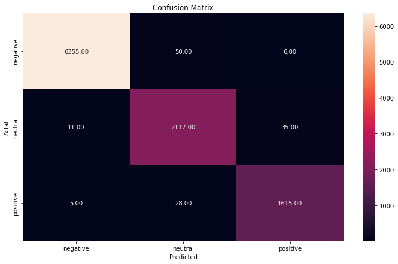

```python
y_pred_train = model.predict(X_train)

cm_metrics(y_train, y_pred_train)
```

- The model has performed excellently on the training data, but could be overfitting. We will have to see how it performs on the test data.

### Model performance on the test data

```
              precision    recall  f1-score   support

          -1       0.82      0.88      0.85      2748
           0       0.56      0.50      0.53       928
           1       0.70      0.61      0.65       706

    accuracy                           0.75      4382
   macro avg       0.69      0.66      0.68      4382
weighted avg       0.75      0.75      0.75      4382

Accuracy Score : 0.7537654039251483
```

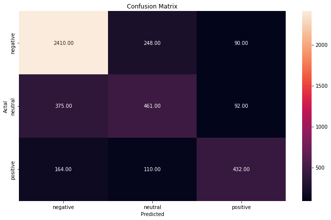

```python
y_pred = model.predict(X_test)

cm_metrics(y_test, y_pred)
```

- The data is definitly overfitting some as this is a good bit lower than the performance on the training data.
- We can see from the confusion matrix that 375 neutral texts were misclassified as negative. This is not that surprsing though given some of the wordcloud results we saw for the neutral cloud.
- There were also 248 negative tweets misclassified as neutral. I think the model might be getting confused as there is definitely a lot of crossover between terms for negative and neutral, especially with reference to Jet Blue's marketing slogan which seems to be misclassified as mostly neutral in the dataset.

### Let's look at the top 40 words from our model with Count Vectorizer

```python
def top40(model, all_features):

    # top_features as top 40 after training the model
    top_features=''

    feat = model.feature_importances_

    features = np.argsort(feat)[::-1]

    for i in features[0:40]:
        top_features+=all_features[i]
        top_features+=','

    wordcloud = WordCloud(background_color = "black", width = 4500,
                              height = 3000).generate(top_features)

    # Display image:
    plt.imshow(wordcloud)
    plt.figure(1, figsize = (12, 12), frameon='equal')
    plt.title('Top 40 features', fontsize = 12)
    plt.axis("off")
    plt.show()
```

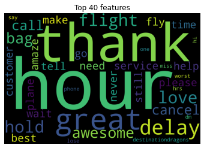

```python
# Get features from the vector
features = cv.get_feature_names_out()

top40(model, features)
```

- Here we see a sampling of some of the positive and negative terms we saw in our original wordclouds, as well as some more generic terms like "flight", but I don't see many neutral exclusive terms.
- The lack of exclusive neutral terms may be part of the reason for the model's confusion between negative and neutral.

# Tf-IDF Vectorizer

```python
from sklearn.feature_extraction.text import TfidfVectorizer
```

```python
# Creating the TfidfVectorizer
tfidf_vectorizer = TfidfVectorizer(max_features = 1000)
```

```python
# fit and transform into vectors
tfidf_vectors = tfidf_vectorizer.fit_transform(data['clean_text']).toarray()
```

```python
# get indexing
print('\nword indexes:')
print(tfidf_vectorizer.vocabulary_)

# tf-idf values
print('\ntf-idf values:')
print(tfidf_vectors)
```

```
word indexes:
{'say': 769, 'plus': 670, 'add': 12, 'experience': 313, 'today': 882, 'must': 583, 'mean': 544, 'need': 588, 'take': 860, 'another': 46, 'trip': 897, 'really': 712, 'entertainment': 290, 'face': 320, 'little': 511, 'big': 104, 'bad': 88, 'thing': 871, 'seriously': 784, 'would': 985, 'pay': 648, 'fli…

tf-idf values:
[[0. 0. 0. ... 0. 0. 0.]
 [0. 0. 0. ... 0. 0. 0.]
 [0. 0. 0. ... 0. 0. 0.]
 ...
 [0. 0. 0. ... 0. 0. 0.]
 [0. 0. 0. ... 0. 0. 0.]
 [0. 0. 0. ... 0. 0. 0.]]
```

# Building the model with Tf-IDF Vectorizer

```python
X = tfidf_vectors

y = data['airline_sentiment'].map({'negative':-1, 'neutral':0, 'positive':1})
```

```python
X_train, X_test, y_train, y_test = train_test_split(X, y, test_size=0.3, random_state=1, stratify=y)
```

```python
print('Training set shape : ', X_train.shape)
print('Test set shape : ', X_test.shape)

print('Percent of classes in training set :')
print(y_train.value_counts(normalize = True))

print('Percent of classes in test set :')
print(y_test.value_counts(normalize = True))
```

```
Training set shape :  (10222, 1000)
Test set shape :  (4382, 1000)
Percent of classes in training set :
-1    0.627177
 0    0.211602
 1    0.161221
Name: airline_sentiment, dtype: float64
Percent of classes in test set :
-1    0.627111
 0    0.211775
 1    0.161114
Name: airline_sentiment, dtype: float64
```

- shape and class distribution matches our other model.

```python
# intialize Random Forest model
model_2 = RandomForestClassifier(n_estimators=100, random_state = 1)

# fitting the model on training set
model_2.fit(X_train, y_train)
```

```
RandomForestClassifier(random_state=1)
```

```
              precision    recall  f1-score   support

          -1       1.00      0.99      0.99      6411
           0       0.96      0.98      0.97      2163
           1       0.98      0.98      0.98      1648

    accuracy                           0.99     10222
   macro avg       0.98      0.98      0.98     10222
weighted avg       0.99      0.99      0.99     10222

Accuracy Score : 0.9865975347290159
```

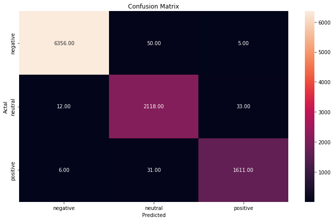

```python
y_pred_train = model_2.predict(X_train)

cm_metrics(y_train, y_pred_train)
```

- Our 2nd model's results for the training data are also very successful with an overall accuracy of nearly 99%
- There is a good chnce that this 2nd model may be overfitting as well.

```
              precision    recall  f1-score   support

          -1       0.80      0.92      0.85      2748
           0       0.62      0.44      0.52       928
           1       0.73      0.57      0.64       706

    accuracy                           0.76      4382
   macro avg       0.72      0.64      0.67      4382
weighted avg       0.75      0.76      0.75      4382

Accuracy Score : 0.7610680054769512
```

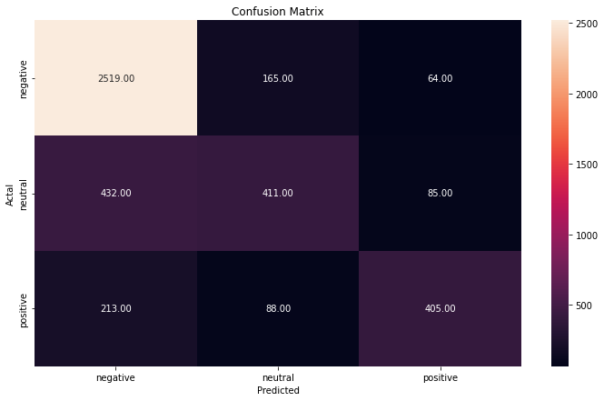

```python
y_pred = model_2.predict(X_test)

cm_metrics(y_test, y_pred)
```

- Not a huge improvement on the test data, but the Tf-IDF model did perform better than the model using Count Vectorizer.
- This model actually misclassified even more neutral texts as negative, but did manage to decrease the negative tweets being misclassified as neutral by more.

```python
def top40(model_2, all_features):

    # top_features as top 40 after training the model
    top_features=''

    feat = model.feature_importances_

    features = np.argsort(feat)[::-1]

    for i in features[0:40]:
        top_features+=all_features[i]
        top_features+=','

    wordcloud = WordCloud(background_color = "black", width = 4500,
                              height = 3000).generate(top_features)

    # Display image:
    plt.imshow(wordcloud)
    plt.figure(1, figsize = (12, 12), frameon='equal')
    plt.title('Top 40 features', fontsize = 12)
    plt.axis("off")
    plt.show()
```

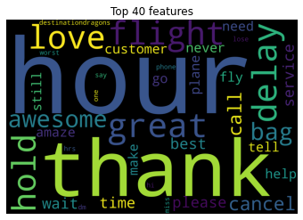

```python
# Get features from the vector
features = tfidf_vectorizer.get_feature_names_out()

top40(model_2, features)
```

# Conclusion

- Overall our models did a decent job on predicting sentiment for the test set, but there is definitely room for improvement.
- One thing hurting our models was the neutral class as many of the neutral words were either generic or crossed over with positive or negative terms. This lack of clearly defined neutral terms caused the model to misclassify many neutral sentiments.
- We could improve on the results by perhaps trying some different machine learning models besides RandomForest.
- Creating an LSTM neural network could probably improve our results even futher than machine learning alone.
- We could also try using some unsupervised learning techniques for vectorization.

# Business Recomendations

- My biggest reccomendation would be to review the dataset to verify the neutral tweet labels. Especially those involving Jet Blue. Fixing these potentially misclassified terms could cut down on the model's confusion between the neutral and negative.
- It may also be beneficial for the company and certainly the model to reduce results to a binary classification such as negative tweets vs. non-negative. This would cut model confusion about the neutral tweets way down and greatly improve model accuracy.